# Practical Machine Learning Course Project

Gerson Guilhem

1/17/2021

## Executive Summary

This report is a completion course work from JHU Data Science Specialization in Coursera. The goal is to build a model that can predict how well a individuals do their physical activities.

According to the owners of the dataset [Velloso, E.; Bulling, A.; Gellersen, H.; Ugulino, W.; Fuks, H. Qualitative Activity Recognition of Weight Lifting Exercises. Proceedings of 4th International Conference in Cooperation with SIGCHI (Augmented Human ’13) . Stuttgart, Germany: ACM SIGCHI, 2013.], data were collected in the following way:

*“Six young health participants were asked to perform one set of 10 repetitions of the Unilateral Dumbbell Biceps Curl in five different fashions: exactly according to the specification (Class A), throwing the elbows to the front (Class B), lifting the dumbbell only halfway (Class C), lowering the dumbbell only halfway (Class D) and throwing the hips to the front (Class E).”*  
*Read more: http:/groupware.les.inf.puc-rio.br/har#ixzz4TjwzUvQ1*

According to the assignment description in Coursera, the problem statement is as follows: *“One thing that people regularly do is quantify how much of a particular activity they do, but they rarely quantify how well they do it. In this project, your goal will be to use data from accelerometers on the belt, forearm, arm, and dumbell of 6 participants.”*

This report will describe all the processes that lead to the final prediction model, covering all the model building steps with details on each one. In the end, the random forest algorithm on the non-PCA variables was the model that performed better on this task.

## Data Cleaning and EDA

Both training and test sets were already provided in the assignment. An important observation is that the test set does not have the outcome variable we’re interested in (variable *classe*). This is because the students needed to evaluate their model accuracy on the test set through a graded quiz in ths course portal. With that being said, let’s load both sets:

```r
train <- read.csv(file = "https://d396qusza40orc.cloudfront.net/predmachlearn/pml-training.csv")
test <- read.csv("https://d396qusza40orc.cloudfront.net/predmachlearn/pml-testing.csv")
```

The first step was to have a grasp on the data structure:

```r
str(train)
```

```
## 'data.frame':    19622 obs. of  160 variables:
##  $ X                       : int  1 2 3 4 5 6 7 8 9 10 ...
##  $ user_name               : Factor w/ 6 levels "adelmo","carlitos",..: 2 2 2 2 2 2 2 2 2 2 ...
##  $ raw_timestamp_part_1    : int  1323084231 1323084231 1323084231 1323084232 1323084232 1323084232 1323084232 1323084232 1323084232 1323084232 ...
##  $ raw_timestamp_part_2    : int  788290 808298 820366 120339 196328 304277 368296 440390 484323 484434 ...
##  $ cvtd_timestamp          : Factor w/ 20 levels "02/12/2011 13:32",..: 9 9 9 9 9 9 9 9 9 9 ...
##  $ new_window              : Factor w/ 2 levels "no","yes": 1 1 1 1 1 1 1 1 1 1 ...
##  $ num_window              : int  11 11 11 12 12 12 12 12 12 12 ...
##  $ roll_belt               : num  1.41 1.41 1.42 1.48 1.48 1.45 1.42 1.42 1.43 1.45 ...
##  $ pitch_belt              : num  8.07 8.07 8.07 8.05 8.07 8.06 8.09 8.13 8.16 8.17 ...
##  $ yaw_belt                : num  -94.4 -94.4 -94.4 -94.4 -94.4 -94.4 -94.4 -94.4 -94.4 -94.4 ...
##  $ total_accel_belt        : int  3 3 3 3 3 3 3 3 3 3 ...
##  $ kurtosis_roll_belt      : Factor w/ 397 levels "","-0.016850",..: 1 1 1 1 1 1 1 1 1 1 ...
##  $ kurtosis_picth_belt     : Factor w/ 317 levels "","-0.021887",..: 1 1 1 1 1 1 1 1 1 1 ...
##  $ kurtosis_yaw_belt       : Factor w/ 2 levels "","#DIV/0!": 1 1 1 1 1 1 1 1 1 1 ...
```

[output cut: 86 more lines]

We see that we have lots of rows (19,622) and 160 different variables. The first seven variables don’t seem to be interesting for our prediction purpose:

- X is a variable describing each row of the dataset
- username, raw_timestamp_part_1, raw_timestamp_part_2, cvtd_timestamp, new_window and num_window are variables related to the **study design** and are not variables that come from the body sensors placed in the subjects. These should be dropped since they will not be present in any new data that comes from outside this study.

```r
library(dplyr)

train <- train %>%
    select(-c(X, user_name, raw_timestamp_part_1, raw_timestamp_part_2,
              cvtd_timestamp, new_window, num_window))
```

Another fact seems to need adjustment: apparently some numeric columns are being interpreted as factors (e.g. kurtosis_roll_belt) and because of that, empty values are not being treated as such. Since we got rid of all study design variables, all remaining ones come from the body sensors and should all be numeric. We’ll first identify all columns that are treated are factors and change them to a numeric data type.

```r
# Identify factor columns (excluding our outcome variable) and get their names
factor.columns <- train %>% select(-classe) %>% select_if(is.factor) %>% colnames()

# Loop through all factor columns and convert them to numeric
for (i in 1:length(factor.columns)) {
    levels(train[, factor.columns[i]]) <- as.numeric(levels(train[, factor.columns[i]]))
    train[, factor.columns[i]] <- train[, factor.columns[i]] %>%
        as.character() %>%
        as.numeric()
}
```

Now we can check if we have missing variables in the data and which columns have the highest rate of missing values.

```r
# Check missing ratio on the train set
missing.ratio.df <- as.data.frame(colMeans(is.na(train)))
colnames(missing.ratio.df) <- "Missing.Ratio"

# Filter only columns that have missing values
missing.ratio.df <- missing.ratio.df %>% arrange(desc(Missing.Ratio)) %>% filter(Missing.Ratio > 0)

# Display summary of columns that have missing values
summary(missing.ratio.df)
```

```
##  Missing.Ratio
##  Min.   :0.9793
##  1st Qu.:0.9793
##  Median :0.9793
##  Mean   :0.9811
##  3rd Qu.:0.9798
##  Max.   :1.0000
```

We can see that the columns that contain missing values have a missing ratio ranging from 97.9% to 100%. This makes these columns almost useless to our prediction task. Using the command `nrow(missing.ratio.df)` we see that we have 100 columns that can be safely dropped due to their missingness ratio.

```r
# Select names of vars that have high missing ratio
vars.to.be.removed <- missing.ratio.df %>% rownames() %>% unlist()

# Remove vars
train <- train %>% select(-all_of(vars.to.be.removed))
```

Finally, we’ll check if any of the remaining variables are considered **near zero variance** variables with the function `nearZeroVar` from the `caret` package.

```r
library(caret)

# Checking the near zero variables
nearZeroVar(train, saveMetrics = TRUE) %>% filter(nzv == TRUE)
```

```
## [1] freqRatio     percentUnique zeroVar       nzv
## <0 rows> (or 0-length row.names)
```

No NZV vars are found and the data is all cleaned up. We can start the model building process.

## Model Building

Since we still have several potential predictors in our training set, we’ll go on with two approches:

- Run PCA to have a smaller dimensional space and store the principal components in a separate training set
- Keep the original training set so we can compare accuracy between the PCA and non PCA versions of the data afterwards

### Performing PCA

We’ll first remove our outcome variable from the train set and store the resulting data frame in a separate variable. Then we’ll run PCA and check the variance explained in the first 10 dimensions with a scree plot.

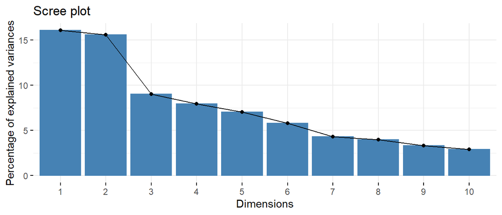

```r
# Removing the ouctome variable from the train set and storing the predictor values in a separate data frame, in order to run PCA.
only.predictors.df <- train %>% select(-classe)

# Perform PCA
prComp <- prcomp(only.predictors.df, scale. = TRUE)

library(factoextra)

# Illustrating the 10 first PC
fviz_eig(prComp)
```

```r
# Seeing the cumulative explained varuance of first 10 Principal Components
as.data.frame(summary(prComp)[6][1]$importance)[,1:10]
```

```
##                             PC1      PC2      PC3      PC4     PC5      PC6
## Standard deviation     2.890758 2.846632 2.162411 2.032151 1.91101 1.733078
## Proportion of Variance 0.160700 0.155830 0.089920 0.079420 0.07023 0.057760
## Cumulative Proportion  0.160700 0.316530 0.406460 0.485870 0.55610 0.613860
##                            PC7      PC8      PC9     PC10
## Standard deviation     1.49665 1.439729 1.310432 1.228341
## Proportion of Variance 0.04308 0.039860 0.033020 0.029020
## Cumulative Proportion  0.65694 0.696800 0.729830 0.758840
```

We’ll now pre process the training set with `caret` and ask it to run PCA with the first 10 principal components. Then we’ll apply the PCA model transformations in the original train dataset and store the resulting reduced variable space in a separate data frame.

```r
# PreProcessing with the first 10 PC
preProc <- preProcess(only.predictors.df, method = "pca", pcaComp = 10)

# Generating the values of the 10 PCs for each row of the original df
train.principal.components <- predict(preProc, only.predictors.df)

# Including the classe variable in the newest PCA data frame
train.principal.components$classe <- train$classe
```

### Testing models

Now that we have the original and a reduced version of the training set, we can start testing different models in both and see which combination yield better accuracy. In order to keep things simple, we’ll start testing two simple but powerful multi-class classification algorithms: **Decision Trees (*rpart*)** and **Random Forests (*rf*)**.

For all those models we’ll train them and perform a 10-fold cross-validation in order to estimate the out of sample error (remember we don’t have the *classe* variable on the test set provided, so we need to validate our model performance on the training set).

#### Decision Trees

```r
# Rpart with PCA dataset
set.seed(1234)
modelFitPCA <- train(classe ~ ., method = "rpart", data = train.principal.components,
                  trControl = trainControl(method = "cv", number = 10,
                                           savePredictions = TRUE))

# Generate a table to store model performance
accuracy.df <- cbind(as.data.frame(modelFitPCA$results) %>%
                         filter(Accuracy == max(Accuracy)) %>%
                         mutate(Model.Parameter = "cp") %>%
                         rename(Parameter.Value = cp) %>%
                         relocate(Parameter.Value, .after = Model.Parameter),
                     data.frame(Method = "rpart", Dataset = "Train with PCA")) %>%
    select(-AccuracySD, -KappaSD)

# Rpart with train data (original variables)
set.seed(1234)
modelFit <- train(classe ~ ., method = "rpart", data = train,
                  trControl = trainControl(method = "cv", number = 10,
                                           savePredictions = TRUE))

# Binding rows to the model performance data frame
accuracy.df <- rbind(accuracy.df,
    cbind(as.data.frame(modelFit$results) %>%
                         filter(Accuracy == max(Accuracy)) %>%
                         mutate(Model.Parameter = "cp") %>%
                         rename(Parameter.Value = cp) %>%
                         relocate(Parameter.Value, .after = Model.Parameter),
                     data.frame(Method = "rpart", Dataset = "Train without PCA")) %>%
        select(-AccuracySD, -KappaSD))

accuracy.df
```

```
##    Accuracy     Kappa Model.Parameter Parameter.Value Method           Dataset
## 1 0.3850264 0.2033861              cp      0.01452785  rpart    Train with PCA
## 2 0.5036174 0.3516261              cp      0.03567868  rpart Train without PCA
```

#### Random Forests

```r
# Rf with PCA dataset
set.seed(1234)
modelFitPCA <- train(classe ~ ., method = "rf", data = train.principal.components,
                  ntree = 4,
                  trControl = trainControl(method = "cv", number = 10,
                                           savePredictions = TRUE))

# Binding rows to the model performance data frame
accuracy.df <- rbind(accuracy.df,
    cbind(as.data.frame(modelFitPCA$results) %>%
                         filter(Accuracy == max(Accuracy)) %>%
                         mutate(Model.Parameter = "mtry") %>%
                         rename(Parameter.Value = mtry) %>%
                         relocate(Parameter.Value, .after = Model.Parameter),
                     data.frame(Method = "rf", Dataset = "Train with PCA")) %>%
        select(-AccuracySD, -KappaSD))

# Rpart with train data (original variables)
set.seed(1234)
modelFit <- train(classe ~ ., method = "rf", data = train, ntree = 4,
                  trControl = trainControl(method = "cv", number = 10,
                                           savePredictions = TRUE))

# Binding rows to the model performance data frame
accuracy.df <- rbind(accuracy.df,
    cbind(as.data.frame(modelFit$results) %>%
                         filter(Accuracy == max(Accuracy)) %>%
                         mutate(Model.Parameter = "mtry") %>%
                         rename(Parameter.Value = mtry) %>%
                         relocate(Parameter.Value, .after = Model.Parameter),
                     data.frame(Method = "rf", Dataset = "Train without PCA")) %>%
        select(-AccuracySD, -KappaSD))

accuracy.df
```

```
##    Accuracy     Kappa Model.Parameter Parameter.Value Method           Dataset
## 1 0.3850264 0.2033861              cp      0.01452785  rpart    Train with PCA
## 2 0.5036174 0.3516261              cp      0.03567868  rpart Train without PCA
## 3 0.8977159 0.8705368            mtry      6.00000000     rf    Train with PCA
## 4 0.9818569 0.9770477            mtry     27.00000000     rf Train without PCA
```

We got way better results with random forests, either with the PCA as well as with the non-PCA variables.

## Conclusions

Among all the tested models, a random forest on the **non-PCA training data** with parameters mtry = 27 and ntree = 4 had the best model performance (higher accuracy and kappa). The estimated out of sample error is about 1.81%.

[figure not shown]

```r
imp.plot <- varImp(modelFit)$importance
imp.plot <- head(imp.plot, 10)
ggplot(imp.plot, aes(x = forcats::fct_reorder(rownames(imp.plot), Overall), y = Overall)) +
    geom_segment(aes(xend = rownames(imp.plot), yend = 0)) +
    geom_point(size = 4, color = "steelblue") +
    coord_flip() +
    theme_bw() +
    xlab("") + ylab("Importance") +
    ylim(c(0, max(imp.plot$Overall) * 1.1)) +
    geom_text(aes(x = forcats::fct_reorder(rownames(imp.plot), Overall), y = Overall + 5, label = format(round(Overall, digits = 2), nsmall = 2)), nudge_y = 1.7) +
    ggtitle(label = 'Importance of Variables when predicting "classe" (Top 10)',
            subtitle = "Random Forest model on the non-PCA variables with ntree=4 and mtry=27")
```

The *roll_belt* variable was the most important feature when determining the accuracy of the exercise performed by the subjects. Although these results may indicate an overfitted model, it scored 100% on the 20 observations in the test set (graded in Coursera), so it performed well on new observations as well. It is important to mention the results obtained with random forests in the PCA dataset. Although its accuracy wasn’t as high as the non-PCA training data, it was able to achieve a high prediction accuracy with much smaller dimension space and with a smaller mtry paramater value. The PCA random forest model is less likely to be overfit.